# MetFlow tutorial

Xiaotao Shen and Dr. Zheng-Jiang Zhu

Interdisciplinary Research Center on Biology and Chemistry, Shanghai Institute of Organic Chemistry, Chinese Academy of Sciences.

shenxt@sioc.ac.cn  
jiangzhu@sioc.ac.cn

26 June 2019

[figure not shown]

# 1 Data Preparation

MetFlow requires the import of the following files, including:

- One or multiple MS1 peak tables (.csv format),
- A table for sample information (.csv format).

## 1.1 Prepare MS1 peak tables

The MS1 peak table is a list of metabolic peaks with annotated m/z, retention times (RTs) and peak abundances.

### 1.1.1 Untargeted metabolomics data

LC-MS or GC-MS untargeted metabolomics data can be generated using processing sortware, such as XCMS or MS-DIAL. The peak table from software must be modified for `MetFlow`.

- The format of MS1 peak table must be csv;
- The first column is the peak name (“name”);
- The second column is the mass-to-charge ratio (“mz”);
- The third column is the retention time (“rt”);
- The unit of retention time must be second (not minute);
- Other columns are peak abundances of MS1 peaks in each sample.

**IMPORTANT:** the order and names of the first three columns must be “name”, “mz”, and “rt”.

**Note:** If you use `fillPeaks` function in XCMS to process data, there will be no missing values (MV) in the MS1 peak table.

The final generated MS1 peak table should look like:

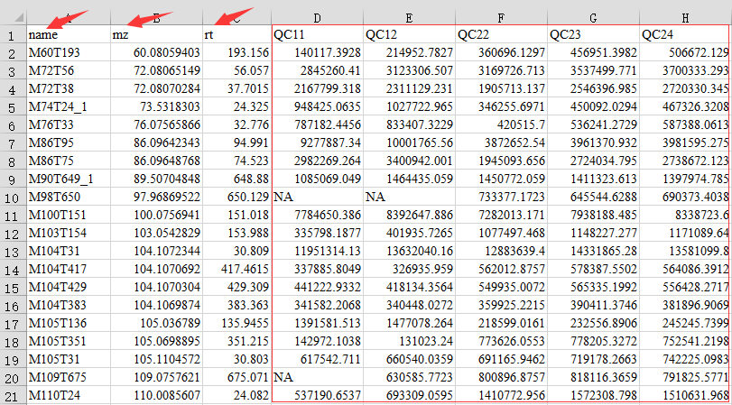

### 1.1.2 Targeted metabolomics data

For targeted metabolomics data, such as MRM, because there is no accurate m/z, so users must assign pseudo m/z values for each peak.

## 1.2 Prepare a sample information file

The sample information file (.csv format) is designed to describe the sample injection order, class, batch and group information. The first column is named as “sample.name”, while the second column is named as “injection.order”, the third column is “class”, the fouth column is “batch” and the fifth column is “group”. “class” is used to descibe the class of samples: subject sample (“Subject”) or QC sample (“QC”). The “group” is used to describe the group information of samples, and QC samples should be names as “QC”. The sample information file should look like:

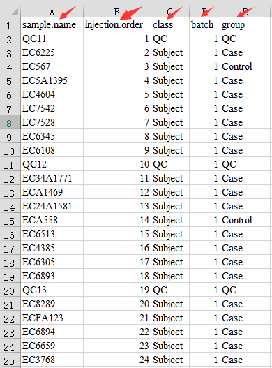

**NOTE:** The “sample.name” column in sample information file must be the **EXACTLY** same as the sample names in the MS1 peak table.

## 1.3 Important notes for data preparation

- In the MS1 peak table, make sure that no “-” or blank appears in the peak name or sample name. If there are some symbols that cannot be recognized by our program, the data processing may be failed.
- The “sample.name” column in sample information file must be the **EXACTLY** same as the sample names in the MS1 peak table.
- Please make sure that sample information (.csv format) and MS1 peak table (.csv format) are separated by comma. Because in some countries or regions (European and some French-speaking regions), the default separator is semicolon. You can open the sample information or MS1 peak table with notepad or other text editors to check whether they are separated by comma.

# 2 Log In or Sign Up

## 2.1 Sign up

If you are using `MetFlow` for the first time, please sign up first.

1. Click “Sign up” tab;
2. Enter your information;
3. Click “Sign up” button.

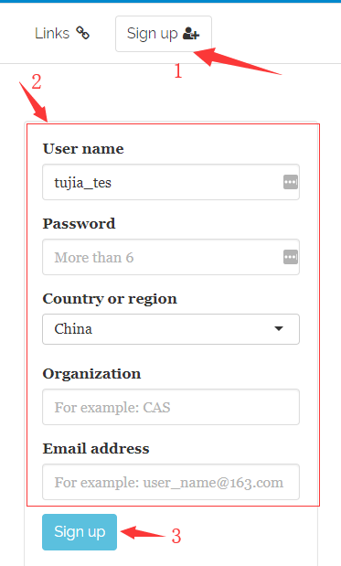

## 2.2 Log in

1. Click “Log in & Account” tab;
2. Enter your user name and password;
3. Click “Log in” button.

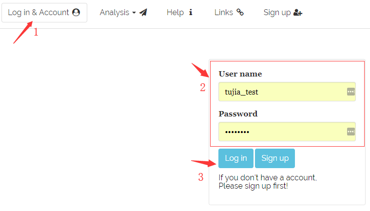

# 3 Data Cleaning

Data cleaning is implemented as a step-wised and standardized workflow under “Data Cleaning” tab. Users should process data step by step.

## 3.1 Upload Data Files

1. Enter the project name;
2. Select the MS1 peak tables (.csv format) and Sample information (.csv format);
3. Or you can use demo data;
4. Click “Submit” button to upload data.

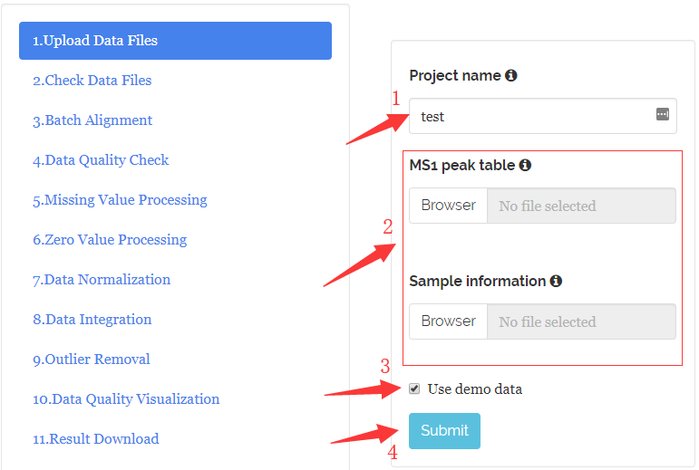

## 3.2 Check Data Files

Then `MetFlow` check the data format of MS1 peak tablss and sample information. If there are error in you data, please click `Previous` to check your data and upload again. If there is no error, you can click `Next` for the next step.

## 3.3 Batch Alignment

### 3.3.1 Parameter setting

1. Set parameters for rough alignment;
2. Click `Submit` for batch alignment.

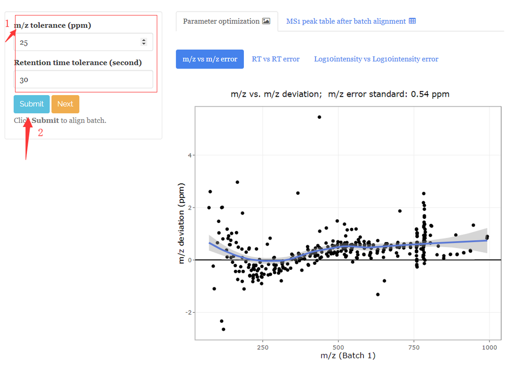

### 3.3.2 Result

1. The “Parameter optimization” tab shows the m/z error, RT error and log10intensity error deviation in rough alignment.
2. The “MS1 peak table after batch alignment” tab shows the aligned MS1 peak table, users can click “Download” to download it.
3. Then click “Next” for the next step.

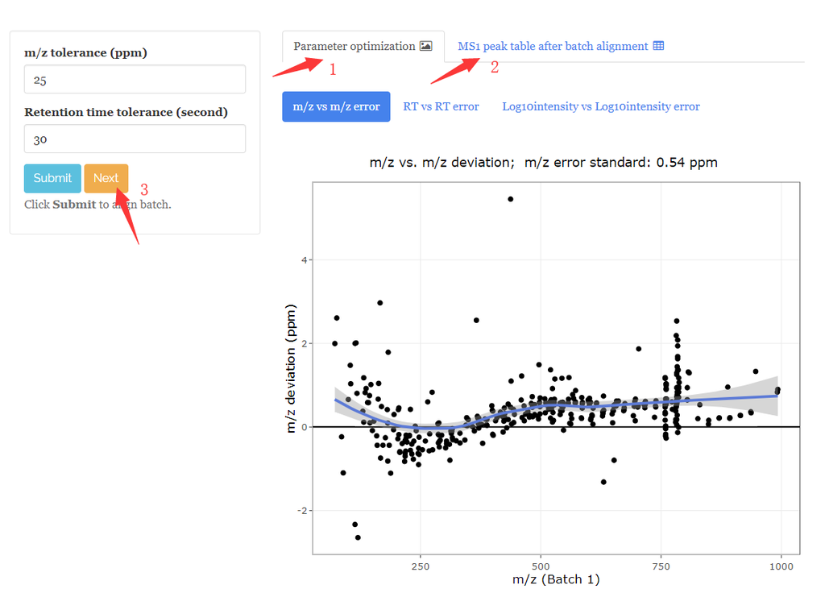

## 3.4 Data Quality Check

Then the data quality is visually checked using 7 different creteria:

1. Data profile: m/z vs RT vs log10(intensity);
2. Missing value distribution: Missing value ratios in peaks and samples;
3. Zero value distribution: Zero value ratios in peaks and samples;
4. RSD distribution: RSD distribution in QC samples, you can also use different group to calculate RSD;
5. PCA score plot: PCA score plot of different batches;
6. QC intensity boxplot: QC auto-scaled intensity boxplot in different batches;
7. QC correlation: The correlations of QC samples;
8. All the figures can be downloaded. Then click “Next” for the next step.

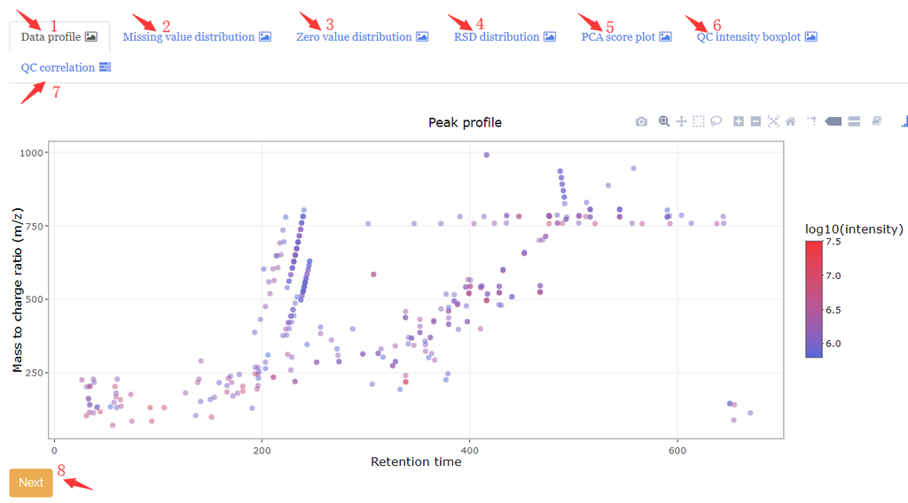

## 3.5 Missing Value Processing

### 3.5.1 Parameter setting

1. Set parameters for missing value processing;
2. Click `Submit`.

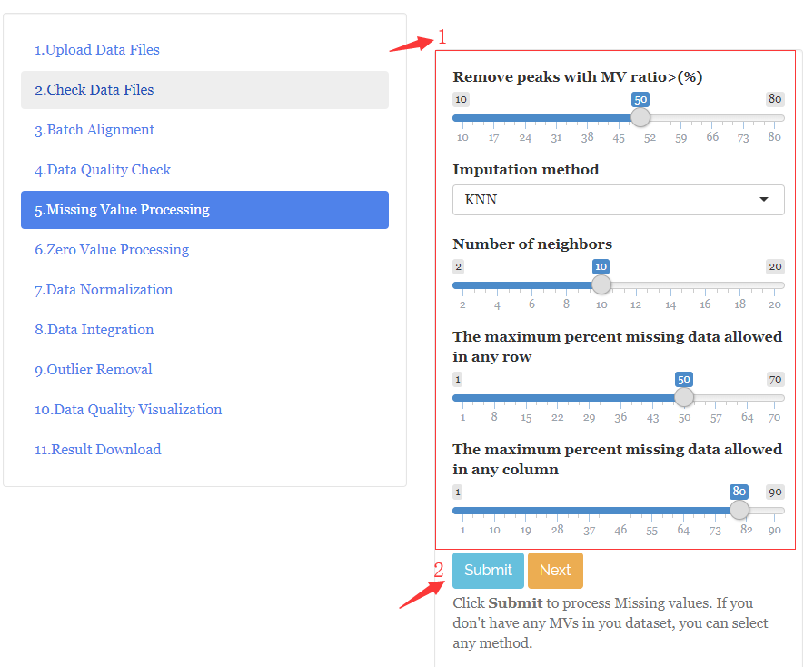

### 3.5.2 Results

1. Summary: Show the peaks which are removed from the dataset;
2. MS1 peak table (after MV processing): You can download the MS1 peak table after MV processing;
3. Click `Next`.

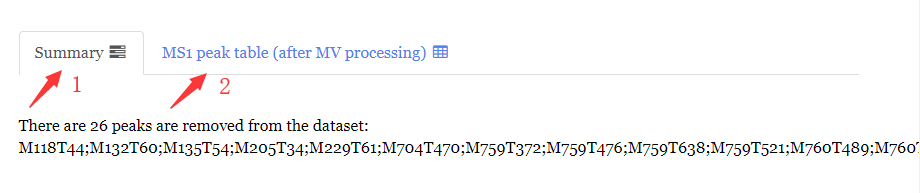

## 3.6 Zero Value Processing

1. Set parameters for zero value processing;
2. Click `Submit`.
3. Summary: Show the peaks which are removed from the dataset;
4. MS1 peak table (after zero processing): You can download the MS1 peak table after zero processing;
5. Click `Next`.

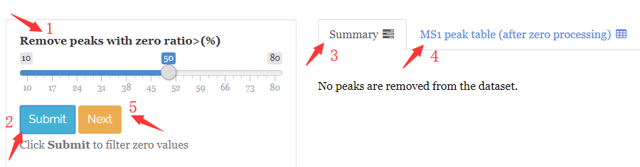

## 3.7 Data Normalization

### 3.7.1 Parameter setting

1. Set parameters for data normalization;
2. Click `Submit`.

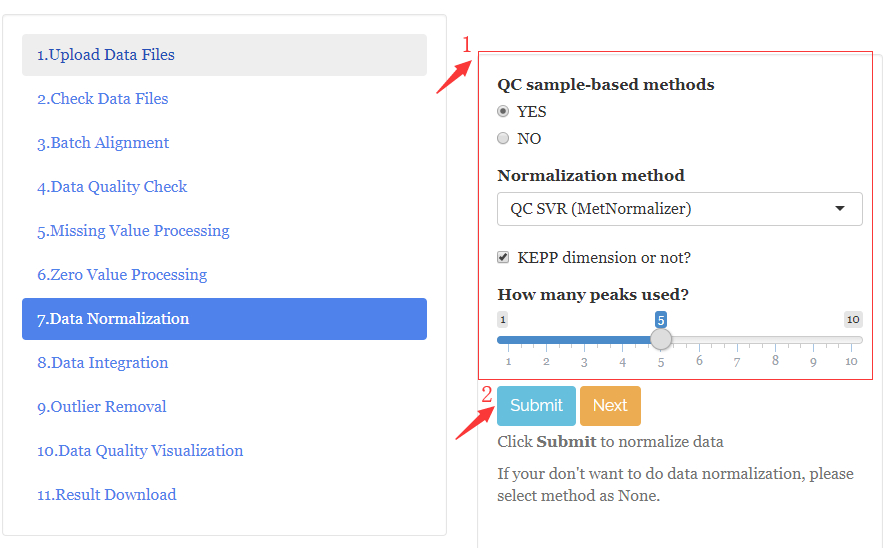

### 3.7.2 Results

#### 3.7.2.1 Summary

1. QC intensity box plot before normalization;
2. QC intensity box plot after normalization;
3. RSD comparison;
4. The distribution of RSDs of peaks.

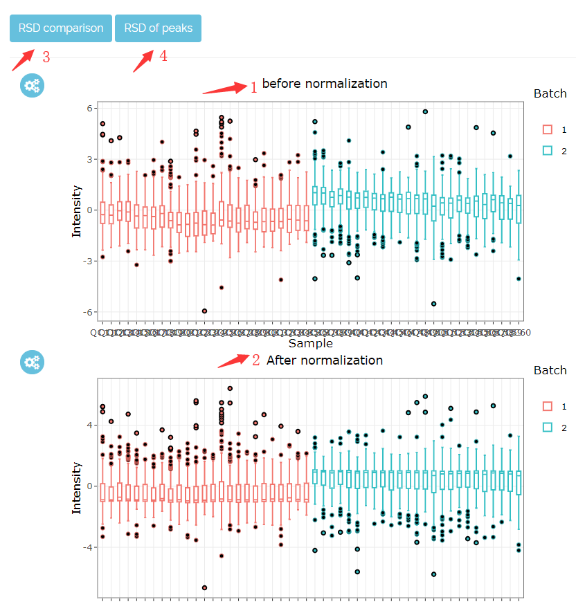

#### 3.7.2.2 MS1 peak table (after data normalization)

1. For each peak, you can select it, then click “Before normalization” or “After normalization” to show it’s intensity drift.
2. Click `Next`.

## 3.8 Data Integration

### 3.8.1 Parameter setting

1. Set parameters for data integration;
2. Click `Submit`.

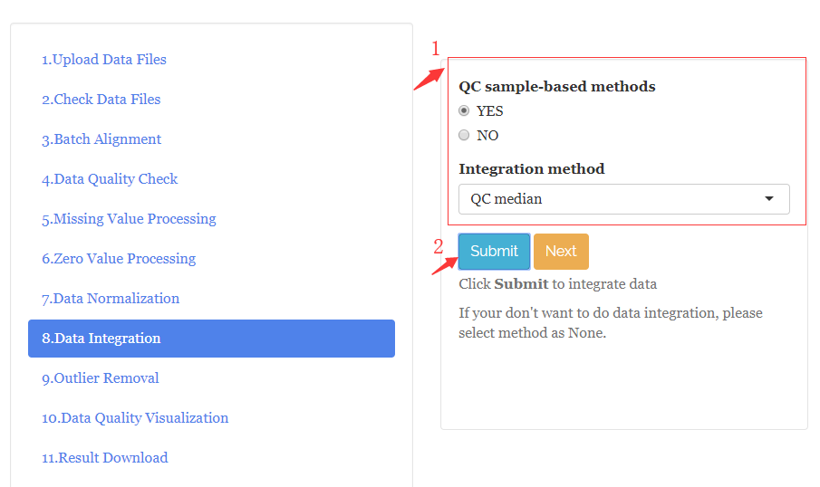

Like data normalization, you can also see the single peak intensity plot, QC auto-intensity boxplot, RSD comparison plot and RSD of peaks. Then click “next” for next step.

## 3.9 Outlier Removal

### 3.9.1 Parameter setting

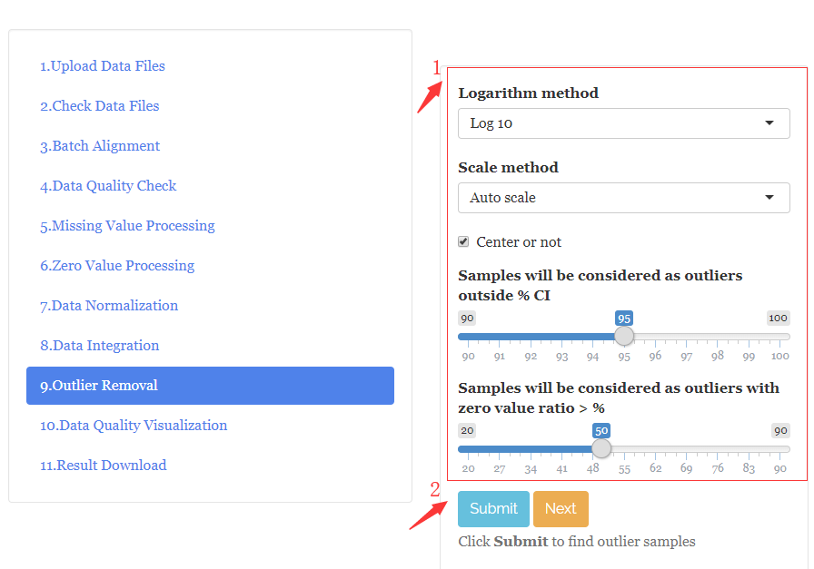

### 3.9.2 Delete outlier samples

1. The information outlier samples;
2. Select outlier samples which you want to remove;
3. Click `Delete`;
4. Click `Submit` again.

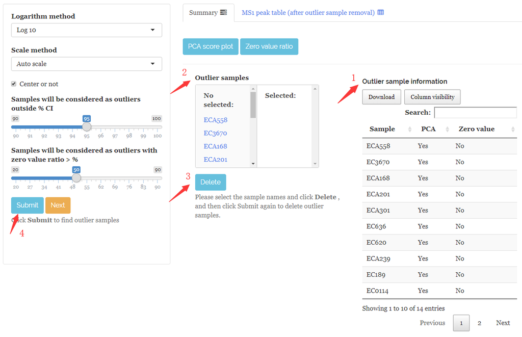

## 3.10 Data Quality Visualization

`MetFlow` also visually assesses the data quality after data cleaning.

## 3.11 Result Download

1. Click “Generate HTML Summary” to generate analysis report (html format);
2. Then click “Download HTML Summary” to download the analysis report;
3. Click “Generate Analysis Result” to generate analysis result (zip foramt);
4. Then click “Download Analysis Result” to download the analysis result.

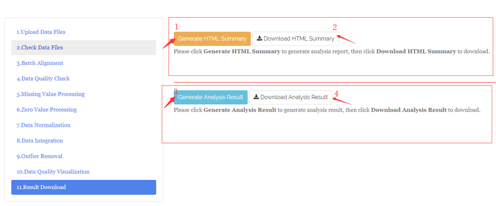

# 4 Differential Metabolite Discovery

Differential metabolite discovery analysis is implemented as a step-wised and standardized workflow under “Differential Metabolite Discovery” tab. Users should process data step by step.

## 4.1 Upload Data Files

This step is same as “Data Cleanning”.

## 4.2 Check Data Files

This step is same as “Data Cleanning”.

## 4.3 Univariate Analysis

### 4.3.1 Parameter setting

1. Set parameters for univariate analysis;
2. Click `Submit`.

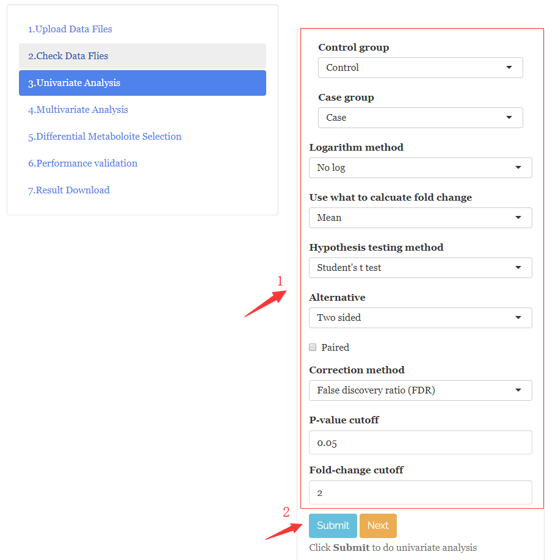

### 4.3.2 Results

1. Volcano plot: The volcanplot is utilized to visualized the differential metabolites.;
2. Fold change and P-value: Fold-changes and P-values for all peaks.

## 4.4 Multivariate Analysis

### 4.4.1 Set parameters

1. Set parameters for multivaraite analysis;
2. Click “Submit”.

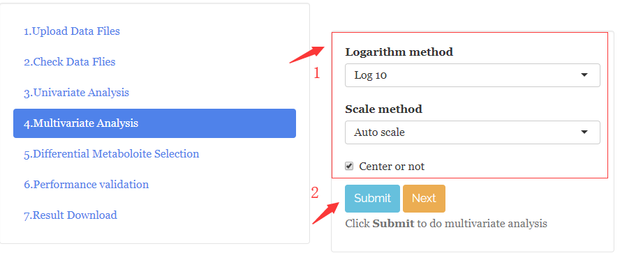

### 4.4.2 Results

#### 4.4.2.1 PCA analysis

The PCA score plot.

#### 4.4.2.2 PLS analysis

1. Click “Q2cum” and select the ncomp with the biggest Q2cum, and then click “Submit”;
2. Click “Q2cum&R2cum” to see the final Q2cum and R2 cum of the PLS model.

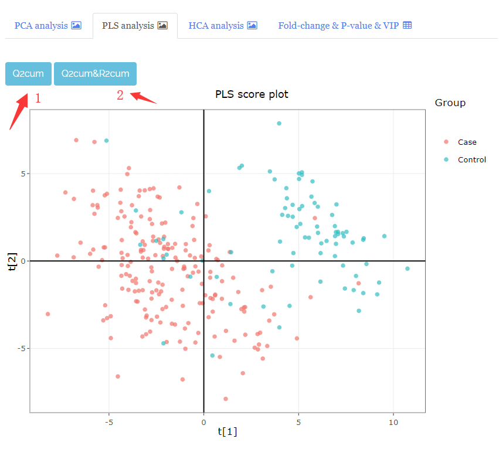

#### 4.4.2.3 HCA analysis

1. Click “Parameter setting” to set parameters for HCA analysis;
2. Click “Download” to download heatmap.

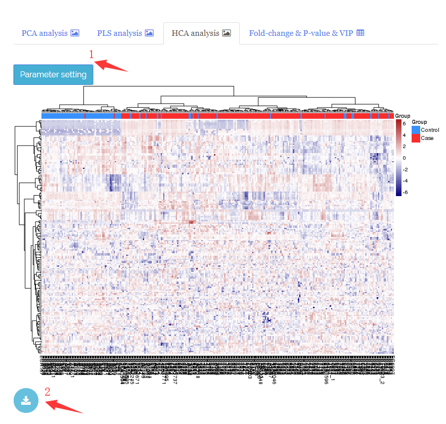

#### 4.4.2.4 Fold-change&P-value&VIP

Fold-changes, P-values and VIP values for all peaks.

## 4.5 Differential Metabolite Selection

1. Set parameters;
2. Click `Submit`;
3. 3D plot for visualization of differential metabolite selection;
4. Differential metabolite table.

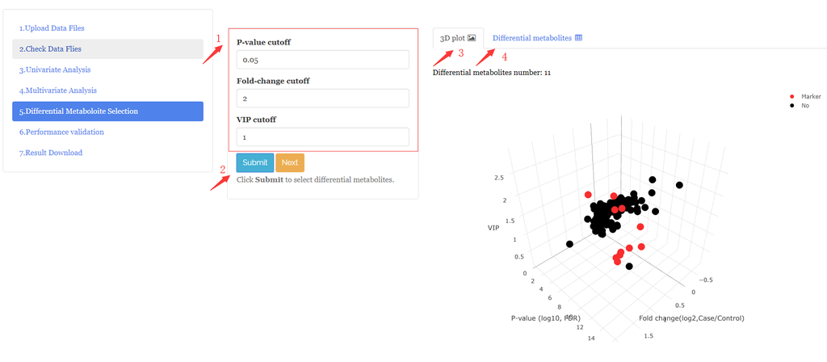

## 4.6 Performance Validation

### 4.6.1 Upload validation dataset

1. If you have validation dataset, please select them and click “Upload”;
2. Click “Submit”.

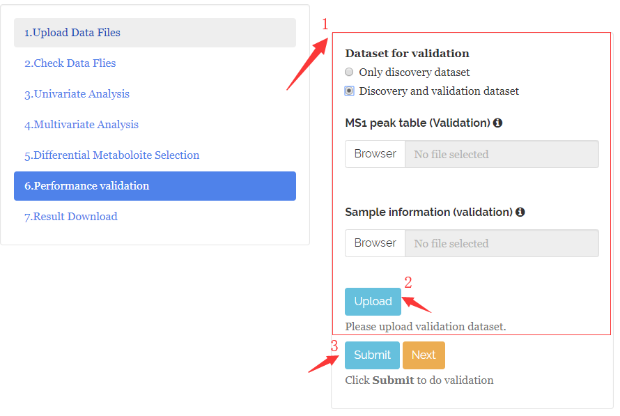

### 4.6.2 Results

#### 4.6.2.1 PCA, PLS and HCA analysis

“PCA analysis”, “PLS analysis” and “HCA analysis” are performed using the differential metabolites in your discovery dataset and validation dataset.

#### 4.6.2.2 ROC analysis

1. Select prediction model you want to use. There are four models, PLS, random forest, support vector machine and logistic regression;
2. Click “Submit”.

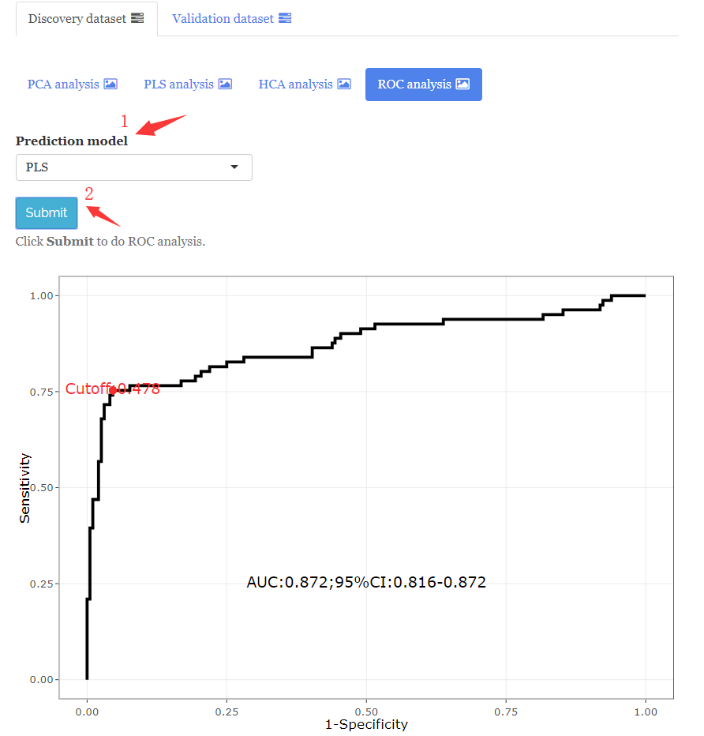

## 4.7 Result Download

1. Click “Generate HTML Summary” to generate analysis report (html format);
2. Then click “Download HTML Summary” to download the analysis report;
3. Click “Generate Analysis Result” to generate analysis result (zip foramt);
4. Then click “Download Analysis Result” to download the analysis result.

[figure not shown]

# 5 Pathway Enrichment Analysis

Pathway enrichment analysis is implemented as a step-wised and standardized workflow under “Pathway Enrichment Discovery” tab. Users should process data step by step.

## 5.1 Paste Differential metabolites/Peaks

1. Enter the project name;
2. Then click `Metabolite type` to select which type of metabolites you want to provide, `KEGG ID` is KEGG ID of metabolites, `Peak (m/z)` is the m/z values of peaks;
3. Paste KEGG ID or m/z values, one row one ID or m/z. If you don’t paste your values, the demo data will be used;
4. Then click “Submit”.

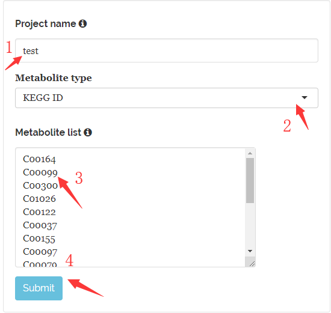

### 5.1.1 Paste differential peaks (m/z)

If you paste m/z values of differential peaks, you must set the parameters for metabolite identification.

- Ionization polarity: `Positive` or `Negative`;
- Adduct type;
- m/z match tolerance;
- Database for metabolite identification.

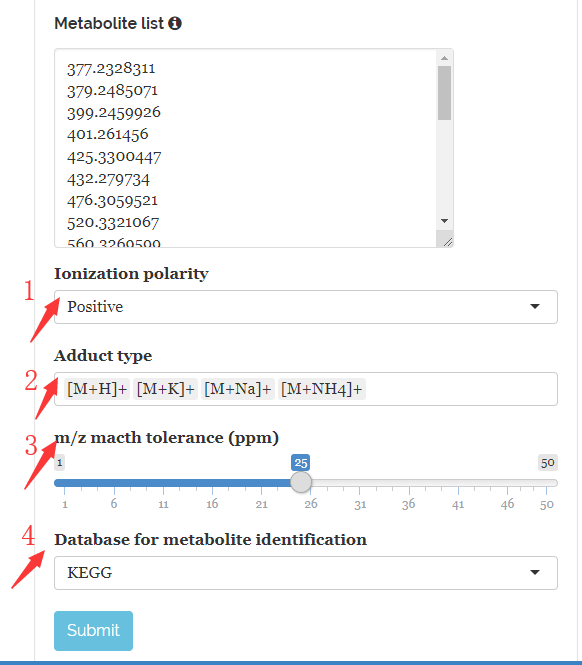

## 5.2 Check Data Files

For `KEGG ID`, MetFlow match them in KEGG database, and shows the match result. For `Peak (m/z)`, the identification rsult is shown.

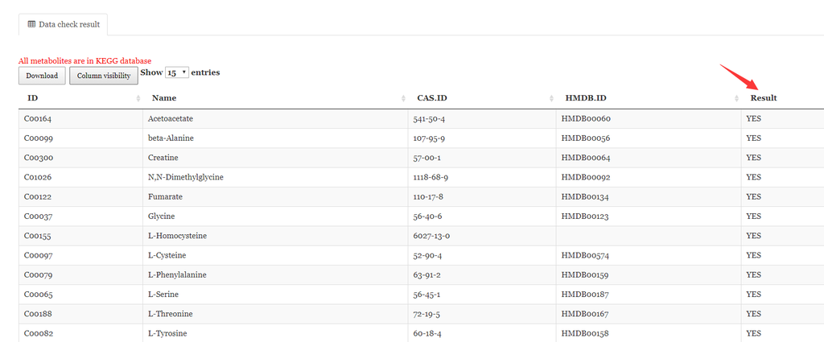

## 5.3 Pathway Enrichment

Please set the parameters for pathway enrichment first, and then click `Submit`.

1. Pathway library;
2. Pathway analysis algorithm: `Hypergeometric test` or `Fisher's Exact Test`;
3. P.value cutoff;
4. Overlap cutoff.

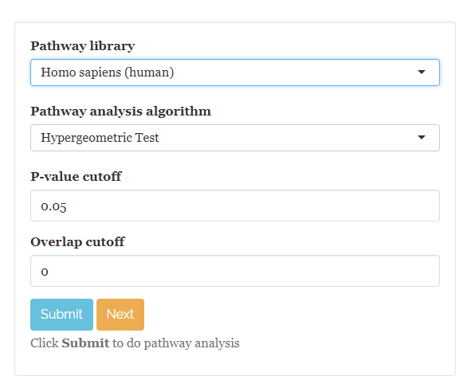

The pathway enrichment result (plot and table) are shown on the right panels.

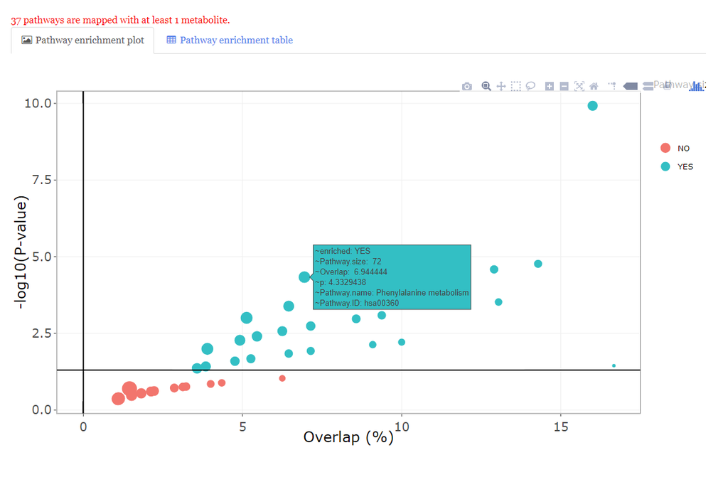

## 5.4 Result Download

The HTML summary and analysis results are generated and downloaded as data cleaning and differential metabolite analysis.